# Daily Mean Radiation Products from Ground-based observations and Satellite data

Marieke Dirksen

September, 2016

```r
.libPaths("/usr/people/dirksen/R-20160725/x86_64-redhat-linux-gnu-library/3.3/")
library(adehabitat)
library(automap)
library(caret)
library(data.table)
library(doParallel)
library(foreach)
library(GSIF)
library(maptools)
library(reshape)
library(raster)
library(rgdal)
library(rhdf5)
library(SDMTools)
data(wrld_simpl)
```

# Color settings for plotting routine

```r
kleur.breaks<-seq(0,500,by=10)
kleur.cols<-terrain.colors(length(kleur.breaks-1))
```

# Daily mean radiation from satellite

```r
pathsat<-"/net/pc150398/nobackup_1/users/meirink/siccs_wouter/SICCS/daymean/"
loc.grid<-"/net/pc150398/nobackup/users/meirink/msg_archive/geo/meteosat9.euro4m.angles.h5"
year.sat<-seq(from=2004,to=2016,by=1)
Y<-year.sat[11]

pathsat.year<-paste0(pathsat,Y)

#selecting a test month
m<-"07"
files.sat<-list.files(path=paste0(pathsat.year,"/",m))
```

```r
setwd(paste0(pathsat.year,"/","07"))

file<-files.sat[1]
d<-gsub("daymean","",file)
d<-gsub("EURO4M.hdf5","",d)
time<-as.POSIXct(paste0(Y,"-",m,"-",d))

#structure of the file
h5ls(file)
```

```
##   group                   name       otype dclass    dim
## 0     /         TOA irradiance H5I_DATASET  FLOAT  x 735
## 1     /     diffuse irradiance H5I_DATASET  FLOAT  x 735
## 2     / diffuse transmissivity H5I_DATASET  FLOAT  x 735
## 3     /      direct irradiance H5I_DATASET  FLOAT  x 735
## 4     /  direct transmissivity H5I_DATASET  FLOAT  x 735
## 5     /                quality H5I_DATASET  FLOAT  x 735
```

```r
data.direct.irradiance<-h5read(file,"direct irradiance")
data.diffuse.irradiance<-h5read(file,"diffuse irradiance")
data.total.irradiance<-data.direct.irradiance+data.diffuse.irradiance
data.total.irradiance<-t(data.total.irradiance)
#the grid file
h5ls(loc.grid)
```

```
##   group name       otype dclass    dim
## 0     /  lat H5I_DATASET  FLOAT  x 735
## 1     /  lon H5I_DATASET  FLOAT  x 735
## 2     / vazi H5I_DATASET  FLOAT  x 735
## 3     /  vza H5I_DATASET  FLOAT  x 735
```

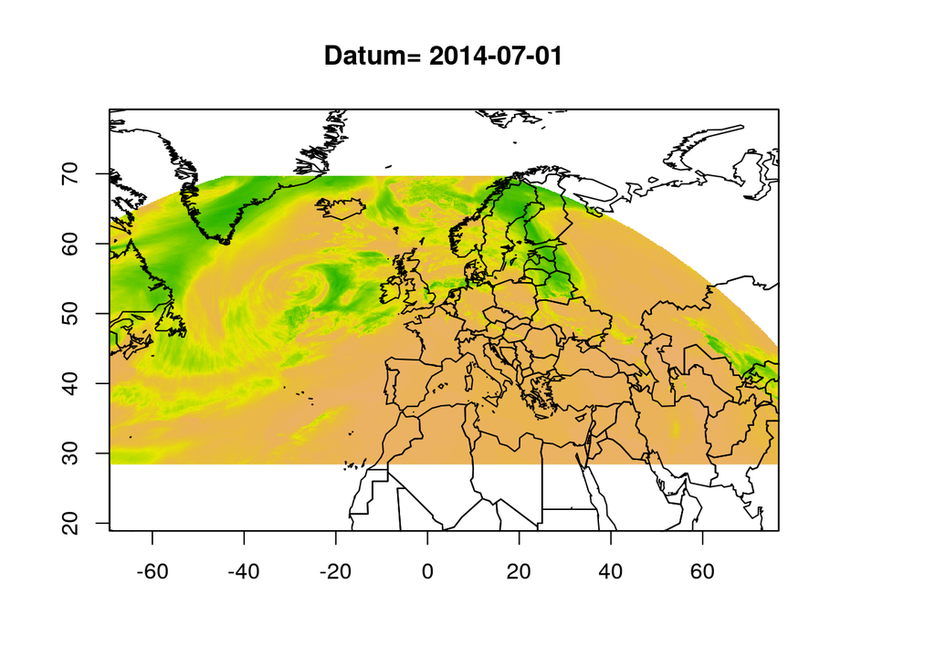

```r
data.lat<-h5read(loc.grid,"/lat") #Latitude
data.lon<-h5read(loc.grid,"/lon") #Longitude

data.lat[which(data.lat==-999)]<-NA # replace no data value with NA (this case -1)
data.lon[which(data.lon==-999)]<-NA # replace no data value with NA (this case -1)

r<-raster(data.total.irradiance,crs=CRS("+init=epsg:4326"),
      xmn=min(data.lon,na.rm=T),
      xmx=max(data.lon,na.rm=T),
      ymn=min(data.lat,na.rm=T),
      ymx=max(data.lat,na.rm=T))
plot(r,main=paste("Datum=",time),col=kleur.cols,breaks=kleur.breaks,legend=F)
plot(wrld_simpl,add=TRUE)
```

# Reprojecting raster and cropping

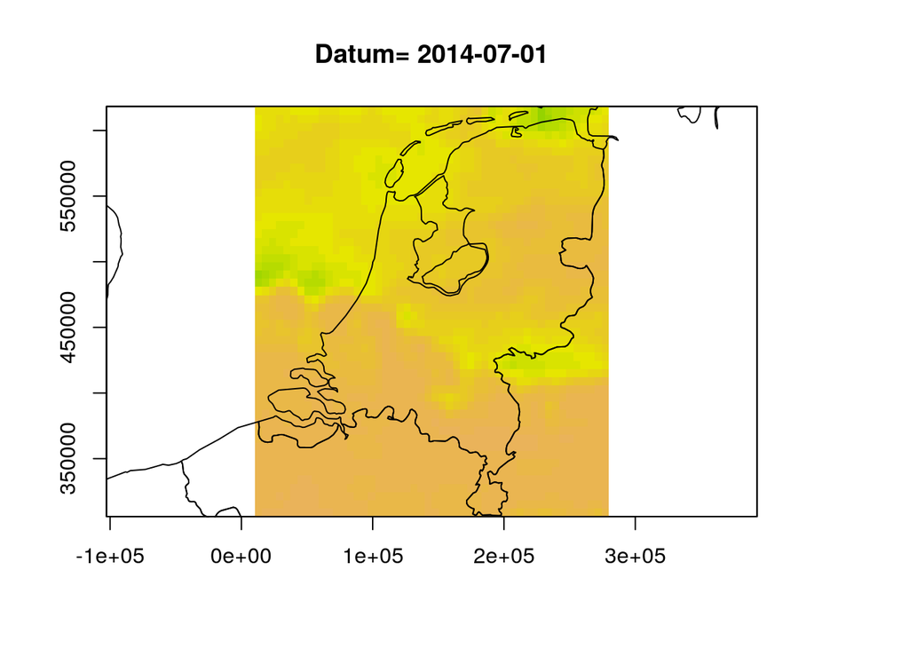

```r
pro=CRS("+init=epsg:28992")

#Natural Earth dataset: unprojected shape files
mymap.unpro=readOGR(dsn='/run/media/dirksen/Elements/Final_R_scripts/NaturalEarthData/ne_10m_admin_0_countries',layer="ne_10m_admin_0_countries") # Read in (unprojected) map data
mymap.pro=spTransform(mymap.unpro, pro) # Reproject the map

mymap.unpro_lakes=readOGR(dsn='/run/media/dirksen/Elements/Final_R_scripts/NaturalEarthData/ne_10m_lakes',layer="ne_10m_lakes") # Read in (unprojected) map data
mymap.pro_lakes=spTransform(mymap.unpro_lakes, pro) # Reproject the map

r<-projectRaster(r,crs=pro)
r.NED<-crop(r,extent(12621.630033977,278621.630033977,305583.0457758,620583.0457758))

plot(r.NED,col=kleur.cols,breaks=kleur.breaks,main=paste("Datum=",time),legend=F)
plot(mymap.pro,add=TRUE)
plot(mymap.pro_lakes,add=TRUE)
```

[figure not shown]

# Data from observations

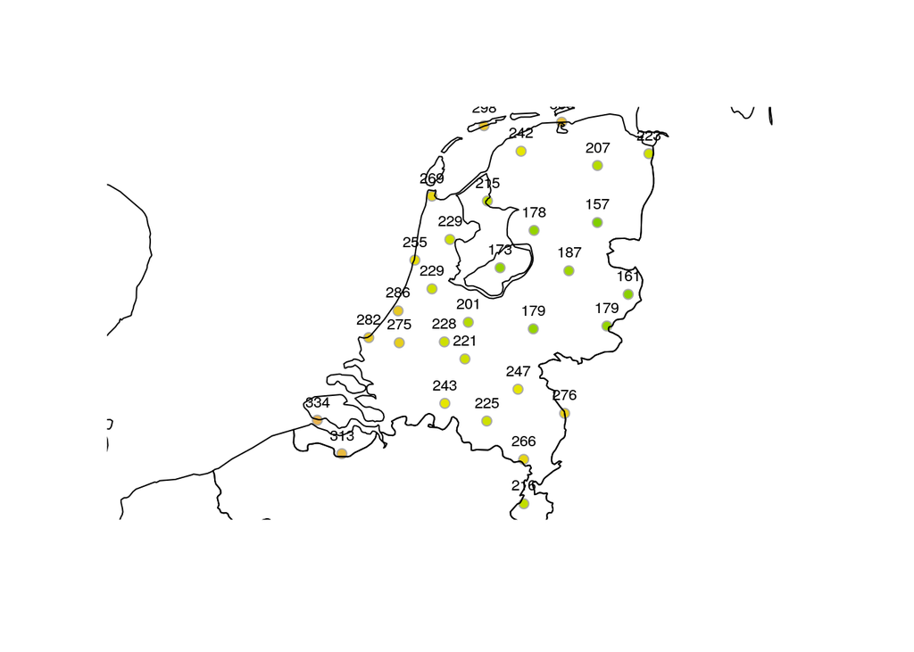

```r
obs<-fread("/nobackup/users/dirksen/Radiation_Obs_Satellite/Observations_data/radiation_KNMI_day.csv")
obs$IT_DATETIME<-as.POSIXct(obs$IT_DATETIME,format="%Y%m%d_%H%M%S_000000")

obs.subset<-obs[which(IT_DATETIME==time),]
obs.subset<-na.omit(obs.subset,cols=c("DS_LAT","DS_LON"))

coordinates(obs.subset)<-~DS_LON+DS_LAT
proj4string(obs.subset)<-CRS("+init=epsg:4326")
obs.subset<-spTransform(obs.subset,pro)
obs.subset$REH1.Q<-obs.subset$REH1.Q24/24

kleur.data<-cut(obs.subset$REH1.Q,breaks=kleur.breaks,include.lowest=TRUE,labels=FALSE)
plot(obs.subset,bg=(kleur.cols[kleur.data]),
     col="darkgrey",pch=21)
text(obs.subset$DS_LON,obs.subset$DS_LAT,round(obs.subset$REH1.Q,0),pos=3,cex=0.7)
plot(mymap.pro,add=TRUE)
plot(mymap.pro_lakes,add=TRUE)
```

# Compare the two products

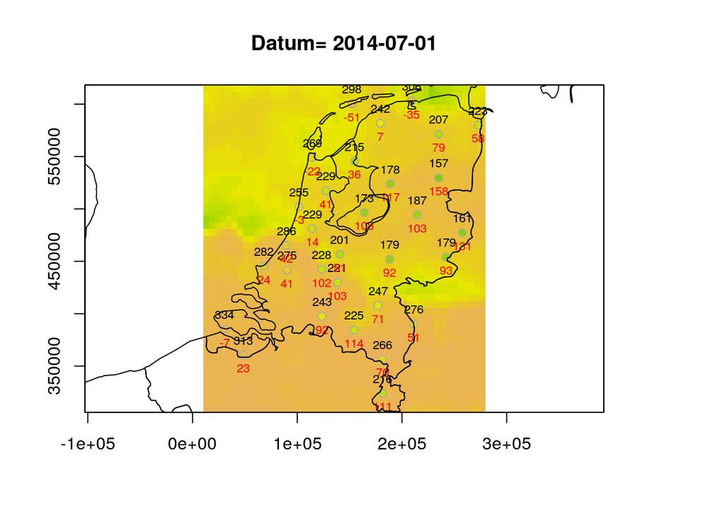

```r
rASC<-asc.from.raster(r.NED)
spdf<-asc2spixdf(rASC)
proj4string(spdf)<-pro

var.Q<-subset(obs.subset,select=REH1.Q)
sat.var<-over(var.Q,spdf)

n<-names(sat.var)
diff<-sat.var[n]-var.Q$REH1.Q

plot(r.NED,col=kleur.cols,breaks=kleur.breaks,main=paste("Datum=",time),legend=F)
plot(obs.subset,bg=(kleur.cols[kleur.data]),
     col="darkgrey",pch=21,add=TRUE)
text(obs.subset$DS_LON,obs.subset$DS_LAT,round(obs.subset$REH1.Q,0),pos=3,cex=0.7)
text(obs.subset$DS_LON,obs.subset$DS_LAT,round(diff[[n]],0),pos=1,cex=0.7,col="red")
plot(mymap.pro,add=TRUE)
plot(mymap.pro_lakes,add=TRUE)
```

# Geostatistical Approach: Kriging interpolation with trend

```r
# Kriging
blocksize = 20000
mxdkrige=Inf # maxdist Krige
# over functions
gridded(spdf)=FALSE;gridded(spdf)=TRUE;fullgrid(spdf) = TRUE
slot(slot(spdf, "grid"), "cellsize") <-rep(mean(slot(slot(spdf, "grid"), "cellsize")), 2)
# over Distshore on Var
distshore.ov=over(obs.subset,spdf)
# Copy the values to Var )
  var = obs.subset
  var$var=distshore.ov$var

  #Prepare input
  field = spdf
  field@data = cbind(field@data, coordinates(field))
  names(field@data) = c("s","x","y")
  var$x = over(var,field)$x
  var$y = over(var,field)$y
  var$s = over(var,field)$s

  # Remove nodata from dataframe based on missing distshore
  var = var[!is.na(var$var),]


    ked_exp <- autoKrige(REH1.Q~var, var, spdf,maxdist=mxdkrige, block=c(blocksize,blocksize), model = c("Exp"), na.action=na.pass, fix.values=c(NA,NA,NA), miscFitOptions = list(merge.small.bins = TRUE))  #log(distshore)
```

```
## [using universal kriging]
```

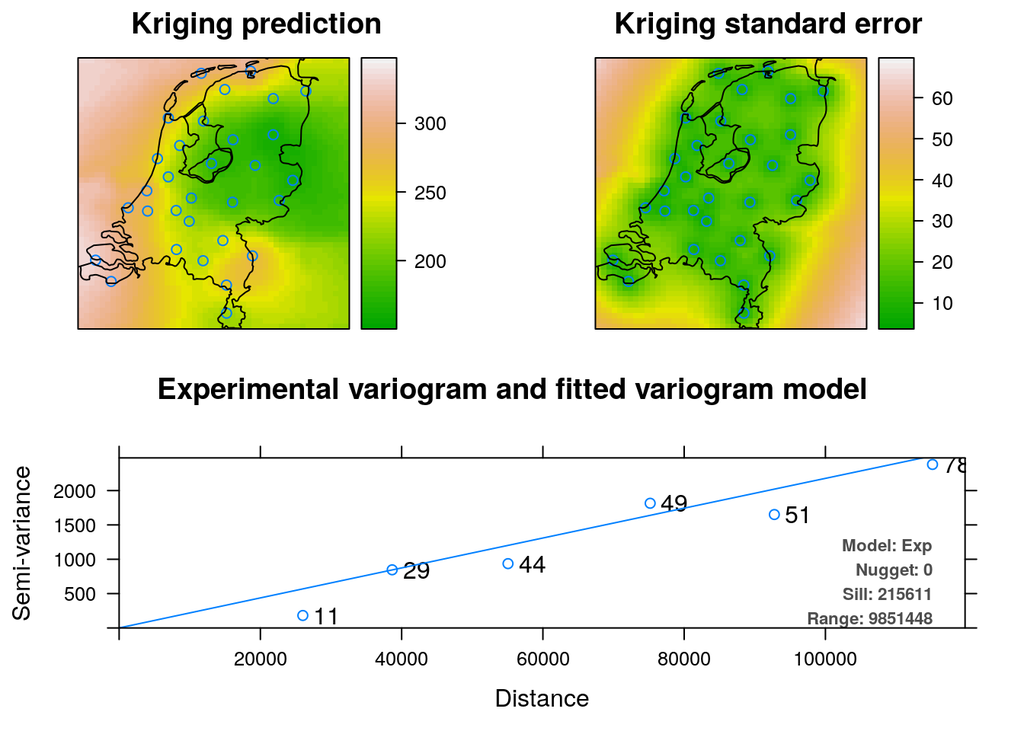

```r
# Krige Cross validation
ked_exp.cv <- autoKrige.cv(REH1.Q~var, var, model = c("Exp"),maxdist=mxdkrige,fix.values=c(NA,NA,NA), miscFitOptions = list(merge.small.bins = TRUE),verbose=c(FALSE,FALSE))
teller <- sum(ked_exp.cv$krige.cv_output$residual^2)
noemer <- sum((var$var-mean(var$var))^2)
ked_exp.r2 <- 1 - teller/noemer
ked.zscoremean <- mean(ked_exp.cv$krige.cv_output$zscore)
ked.zscore.var <- var(ked_exp.cv$krige.cv_output$zscore)

plot(ked_exp,col=kleur.cols,breaks=kleur.breaks,sp.layout=list(pts=list("sp.points",obs.subset,pch=21),mymap.pro,mymap.pro_lakes))
```

```r
print(paste("R2=",round(ked_exp.r2,2)))
```

```
## [1] "R2= 0.52"
```

```r
print(head(ked_exp$krige_output))
```

```
##   var1.pred var1.var var1.stdev
## 1  333.5145 3995.104   63.20683
## 2  332.6599 3811.503   61.73737
## 3  332.3569 3628.939   60.24067
## 4  331.2933 3449.343   58.73111
## 5  329.1231 3271.636   57.19821
## 6  327.5584 3095.118   55.63379
```

# Caret: Testing Machine Learning Models

For grid predictions with the caret package a combination of the caret::train and raster::predict functions is used. The input for the raster::predict function is either a rasterStack or rasterBrick.

- Methods [here](http://topepo.github.io/caret/train-models-by-tag.html#Two_Class_Only.html).
- Some methods of the caret package run in parallel, background information can be found [here](https://cran.r-project.org/web/packages/doParallel/vignettes/gettingstartedParallel.pdf).
- Bug in Caret “Error in e$fun(obj, substitute(ex), parent.frame(), e$data) : worker initialization failed: there is no package called ‘caret’” can be fixed like [this](http://stackoverflow.com/questions/21029019/parallel-execution-of-train-in-caret-fails-with-function-not-found)

```r
#cl<-makeCluster(6)
#registerDoParallel(cl)

obs.subset.Q<-subset(obs.subset,select="REH1.Q")
grid<-as(r.NED,"SpatialPixelsDataFrame")

ov<-over(obs.subset.Q,grid)
ov<-cbind(data.frame(obs.subset.Q["REH1.Q"]),ov)
ov<-rename(ov,c("DS_LON"="x"))
ov<-rename(ov,c("DS_LAT"="y"))

control<-trainControl(method="cv",number=10,repeats=3) #setting a 10 fold-cross validation (best performing)
length<-10 #for the tuneLength of the models

tune.svm<-data.frame(.sigma=100,.C=c(0.25,0.5,1)) #uncertainty measurements (calibration): 10W/m2, uncertainty sat: 30-50W/m2.

set.seed(50)
m1.svmRadial<-caret::train(REH1.Q~layer,data=ov,method="svmRadial",preProcess=c("center","scale","BoxCox"),verbose=FALSE,tuneLength=length,trControl=control,tuneGrid=tune.svm)

set.seed(50)
m2.treebag<-caret::train(REH1.Q~layer,data=ov,method="treebag",preProcess=c("center","scale","BoxCox"),verbose=FALSE,tuneLength=length,trControl=control)

set.seed(50)
m3.rlm<-caret::train(REH1.Q~layer,data=ov,method="rlm",preProcess=c("center","scale","BoxCox"),verbose=FALSE,tuneLength=length,trControl=control)

set.seed(50)
m4.gaussprLinear<-caret::train(REH1.Q~layer,data=ov,method="gaussprLinear",preProcess=c("center","scale","BoxCox"),verbose=FALSE,tuneLength=length,trControl=control)

set.seed(50)
m5.cubist<-caret::train(REH1.Q~layer,data=ov,method="cubist",preProcess=c("center","scale","BoxCox"),verbose=FALSE,tuneLength=length,trControl=control)

results<-resamples(list(svmRadial=m1.svmRadial,treebag=m2.treebag,rlm=m3.rlm,gaussprLinear=m4.gaussprLinear,cubist=m5.cubist))
summary(results)
```

```
##
## Call:
## summary.resamples(object = results)
##
## Models: svmRadial, treebag, rlm, gaussprLinear, cubist
## Number of resamples: 10
##
## RMSE
##                Min. 1st Qu. Median  Mean 3rd Qu.  Max. NA's
## svmRadial     18.72   34.28  39.07 41.44   47.77 65.44    0
## treebag       19.01   30.40  35.48 41.81   53.71 68.18    0
## rlm           11.07   35.07  38.16 44.14   54.10 72.83    0
## gaussprLinear 11.21   35.06  38.19 44.03   53.90 72.12    0
## cubist        23.20   29.57  37.33 41.34   53.76 64.50    0
##
## Rsquared
##                  Min. 1st Qu. Median   Mean 3rd Qu. Max. NA's
## svmRadial     0.02360  0.4112 0.7947 0.6621       1    1    0
## treebag       0.01858  0.6600 0.7794 0.7278       1    1    0
## rlm           0.20810  0.5015 0.9058 0.7453       1    1    0
## gaussprLinear 0.20810  0.5015 0.9058 0.7453       1    1    0
## cubist        0.19970  0.4942 0.7701 0.7207       1    1    0
```

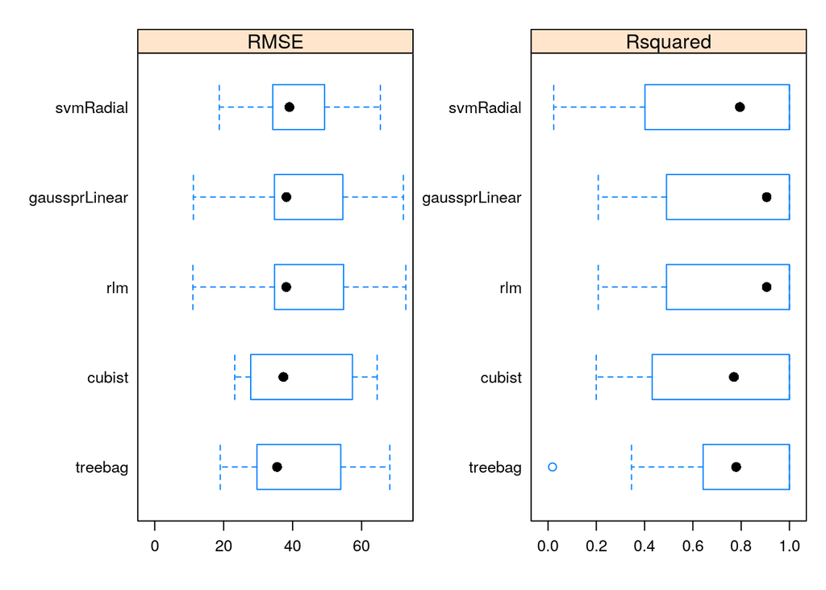

```r
bwplot(results,scales=list(relation="free"),xlim=list(c(0,70),c(0,1)))
```

```r
modelDifferences<-diff(results)
print(modelDifferences) #see str(modelDifferences) for values. Large p-values: the models fail to show any diference in performance (Kuhn&Johnson 2013, p.101 )
```

```
##
## Call:
## diff.resamples(x = results)
##
## Models: svmRadial, treebag, rlm, gaussprLinear, cubist
## Metrics: RMSE, Rsquared
## Number of differences: 10
## p-value adjustment: bonferroni
```

## Model selection

In the previous section we found that differences between the models are too small to select the best performing model. What we don’t want is an under- or overpredicting model. Comparing predictions, observations and residuals helps to find the best fit.

Comparing the models showed the following results:

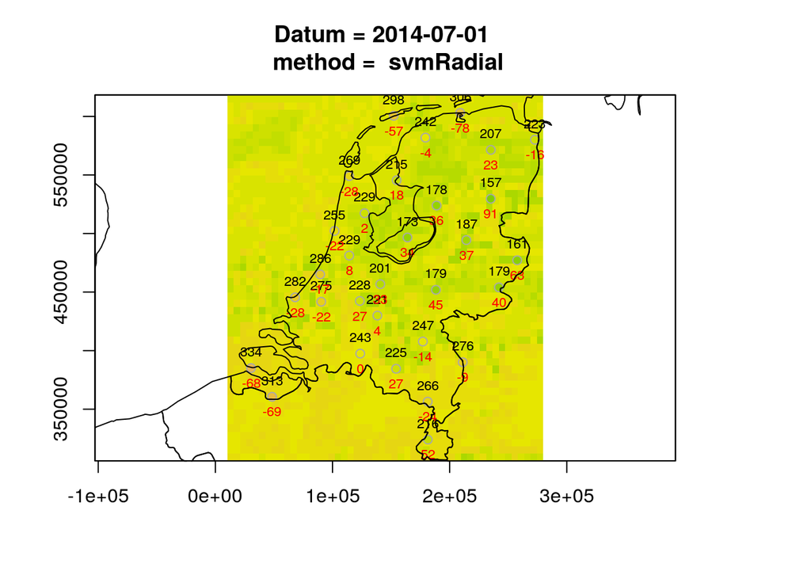

```r
final.model<-m1.svmRadial

st<-stack(grid)
p1.caret<-raster::predict(model=final.model,object=st)

p1.ASC<-asc.from.raster(p1.caret)
p1.spdf<-asc2spixdf(p1.ASC)
proj4string(p1.spdf)<-pro

p1.var<-over(var.Q,p1.spdf)

n<-names(p1.var)
p1.diff<-p1.var[n]-var.Q$REH1.Q

observed<-data.frame(var.Q$REH1.Q)
predicted<-p1.var[n]

plot(p1.caret,col=kleur.cols,breaks=kleur.breaks,main=paste("Datum =",time,"\n","method = ",final.model$method),legend=F)
plot(obs.subset,bg=(kleur.cols[kleur.data]),
     col="darkgrey",pch=21,add=TRUE)
text(obs.subset$DS_LON,obs.subset$DS_LAT,round(obs.subset$REH1.Q,0),pos=3,cex=0.7)
text(obs.subset$DS_LON,obs.subset$DS_LAT,round(p1.diff[[n]],0),pos=1,cex=0.7,col="red")
plot(mymap.pro,add=TRUE)
plot(mymap.pro_lakes,add=TRUE)
```

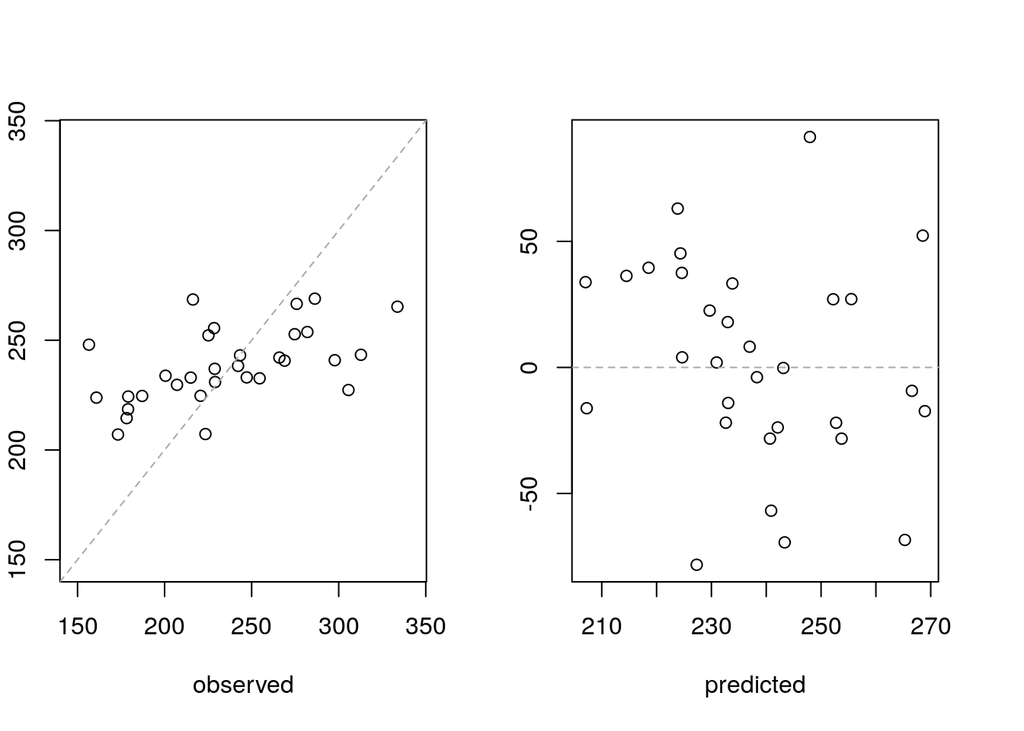

```r
obs.vs.pred<-data.frame(observed,predicted)
pred.vs.res<-data.frame(predicted,p1.diff)
axisRange <- extendrange(c(observed, predicted))

plot.new()
par(mfrow=c(1,2))


plot(obs.vs.pred,xlab="observed",ylab="predicted",ylim=axisRange,xlim=axisRange)
abline(0, 1, col = "darkgrey", lty = 2)

plot(pred.vs.res,xlab="predicted",ylab="residual")
abline(h = 0, col = "darkgrey", lty = 2)
```

# Machine learning models from the GSIF package

Note that these models require at least 50 data points for validation, as this test set is for 1 day with all KNMI observations this is not enough for a prediction. However, it is possible to make model fits. Below an example how to make ML models with GSIF.

```r
m1<-fit.regModel(REH1.Q~layer,rmatrix=ov,grid,method="GLM")
m2<-fit.regModel(REH1.Q~layer,rmatrix=ov,grid,method="rpart")
m3<-fit.regModel(REH1.Q~layer,rmatrix=ov,grid,method="randomForest")
#m4<-fit.regModel(REH1.Q~layer,rmatrix=ov,grid,method="quantregForest")
#m5<-fit.regModel(REH1.Q~layer,rmatrix=ov,grid,method="lme")
m6<-fit.regModel(REH1.Q~layer,rmatrix=ov,grid,method="ranger")

sppoints<-ov
coordinates(sppoints)<-~x+y
spdfpoints<-as(sppoints,"SpatialPointsDataFrame")
proj4string(spdfpoints)<-pro


#m7<-fit.gstatModel(spdfpoints,REH1.Q~layer,grid,family=gaussian(log)) #does not find a fit

#om.rk<-predict(m7,grid) #Validation data critically small (<50) for reliable validation

plot(m3)
plot(m6)
```